# Red Wine Analysis by Jonas Machado Brunetto

#### “density”

Def: The density of water is close to that of water depending on the percent alcohol and sugar content

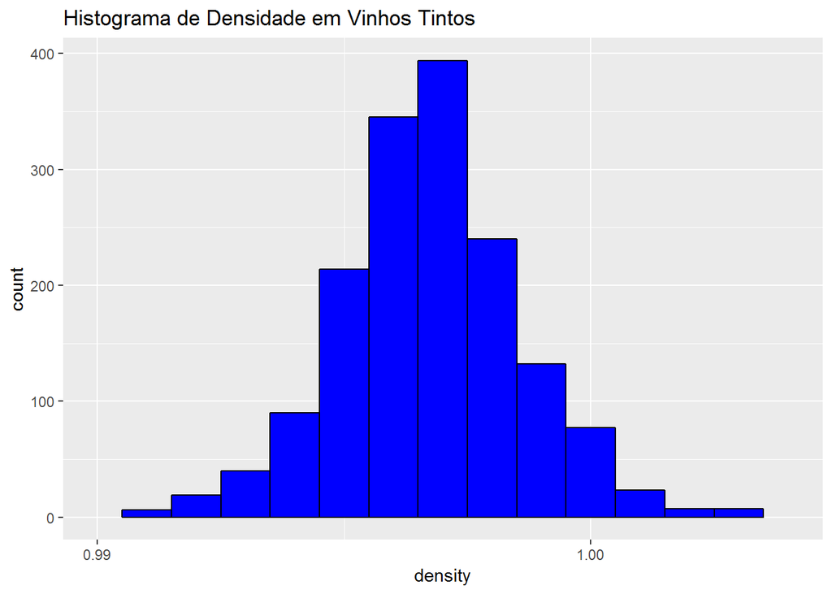

```r
ggplot(data = wine, aes(x=density))+
  geom_histogram(binwidth = .001, color = 'black', fill = 'blue')+
  scale_x_continuous(limits = c(0.9900,1.0040), breaks = seq(0.9900,1.0040,.01))+
  labs(title = 'Histograma de Densidade em Vinhos Tintos')
```

Algo interessante aqui, a variavel density se assemelha a uma distribuição normal.

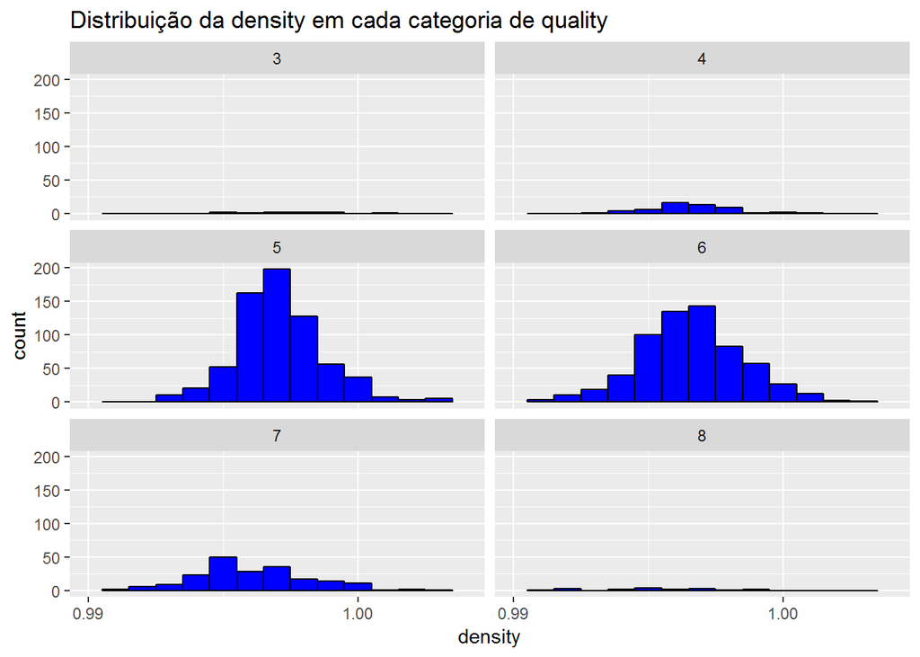

```r
ggplot(data = wine, aes(x=density))+
  geom_histogram(binwidth = 0.001, color = 'black', fill = 'blue')+
  scale_x_continuous(limits = c(0.9900,1.0040), breaks = seq(0.9900,1.0040,.01))+
  facet_wrap(  ~ quality, ncol=2)+
  labs(title = 'Distribuição da density em cada categoria de quality')
```

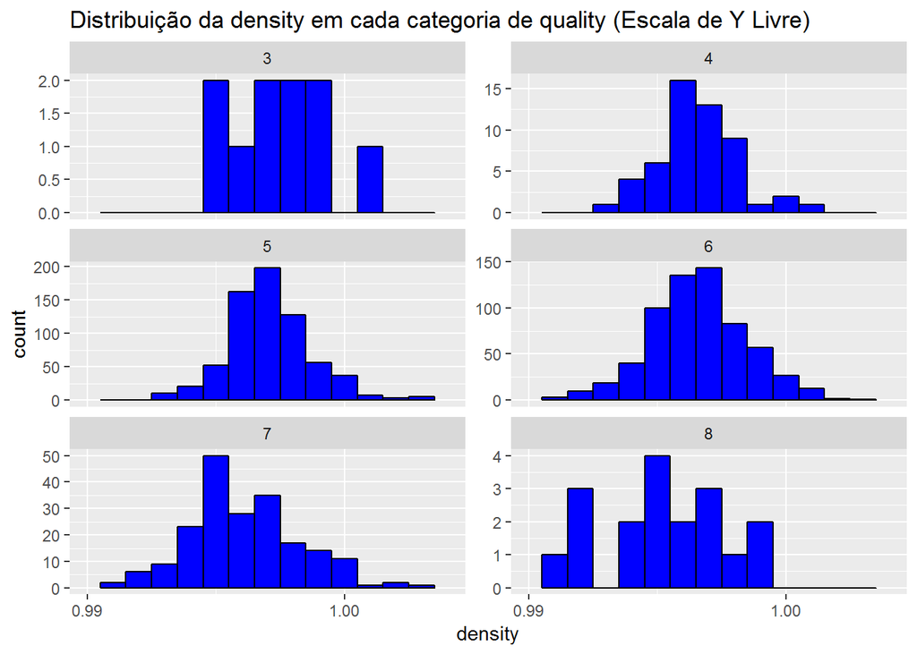

```r
ggplot(data = wine, aes(x=density))+
  geom_histogram(binwidth = .001, color = 'black', fill = 'blue')+
  scale_x_continuous(limits = c(0.9900,1.0040), breaks = seq(0.9900,1.0040,.01))+
  facet_wrap(  ~ quality, ncol=2, scales = 'free_y')+
  labs(title = 'Distribuição da density em cada categoria de quality (Escala de Y Livre)')
```

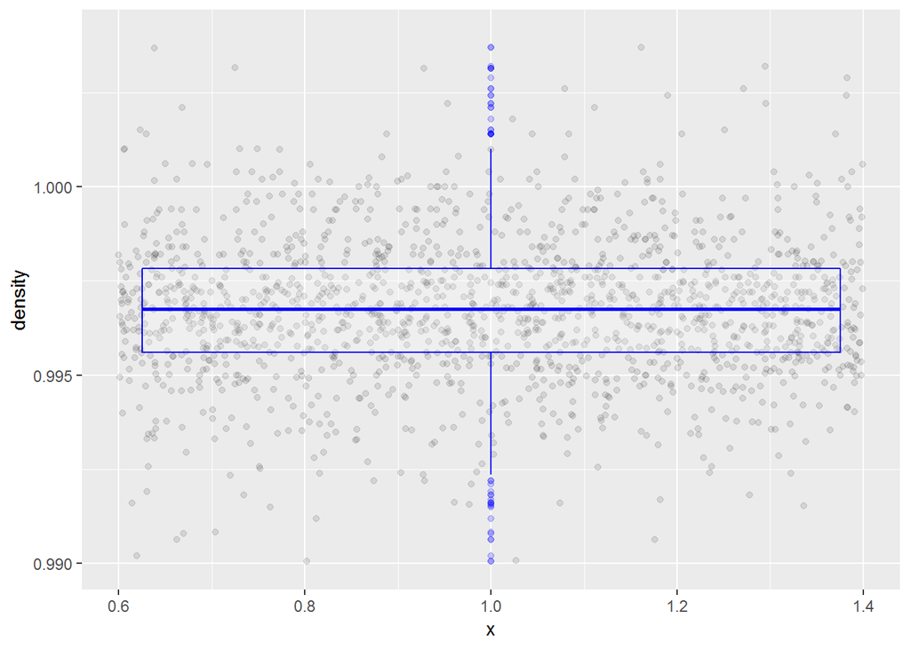

```r
ggplot(wine, aes( x = 1, y = density ), xlab('Count of wines') ) +
               geom_jitter(alpha = 0.1 ) + # Alpha = 10% (10 pontos para virar um ponto completo)
               geom_boxplot(alpha = 0.2, color = 'blue' ) +
               scale_y_continuous(lim = c(0.9900,1.0040))
```

```r
by(wine$density, wine$quality, sum)
```

```
## wine$quality: 3
## [1] 9.97464
## --------------------------------------------------------
## wine$quality: 4
## [1] 52.81675
## --------------------------------------------------------
## wine$quality: 5
## [1] 679.0276
## --------------------------------------------------------
## wine$quality: 6
## [1] 635.8404
## --------------------------------------------------------
## wine$quality: 7
## [1] 198.2248
## --------------------------------------------------------
## wine$quality: 8
## [1] 17.91382
```

```r
by(wine$density, wine$quality, summary)
```

```
## wine$quality: 3
##    Min. 1st Qu.  Median    Mean 3rd Qu.    Max.
##  0.9947  0.9961  0.9976  0.9975  0.9988  1.0008
## --------------------------------------------------------
## wine$quality: 4
##    Min. 1st Qu.  Median    Mean 3rd Qu.    Max.
##  0.9934  0.9957  0.9965  0.9965  0.9974  1.0010
## --------------------------------------------------------
## wine$quality: 5
##    Min. 1st Qu.  Median    Mean 3rd Qu.    Max.
##  0.9926  0.9962  0.9970  0.9971  0.9979  1.0031
## --------------------------------------------------------
## wine$quality: 6
##    Min. 1st Qu.  Median    Mean 3rd Qu.    Max.
##  0.9901  0.9954  0.9966  0.9966  0.9979  1.0037
## --------------------------------------------------------
## wine$quality: 7
##    Min. 1st Qu.  Median    Mean 3rd Qu.    Max.
##  0.9906  0.9948  0.9958  0.9961  0.9974  1.0032
## --------------------------------------------------------
## wine$quality: 8
##    Min. 1st Qu.  Median    Mean 3rd Qu.    Max.
##  0.9908  0.9942  0.9949  0.9952  0.9972  0.9988
```

#### “pH”

Def: Describes how acidic or basic a wine is on a scale from 0 (very acidic) to 14 (very basic); most wines are between 3-4 on the pH scale

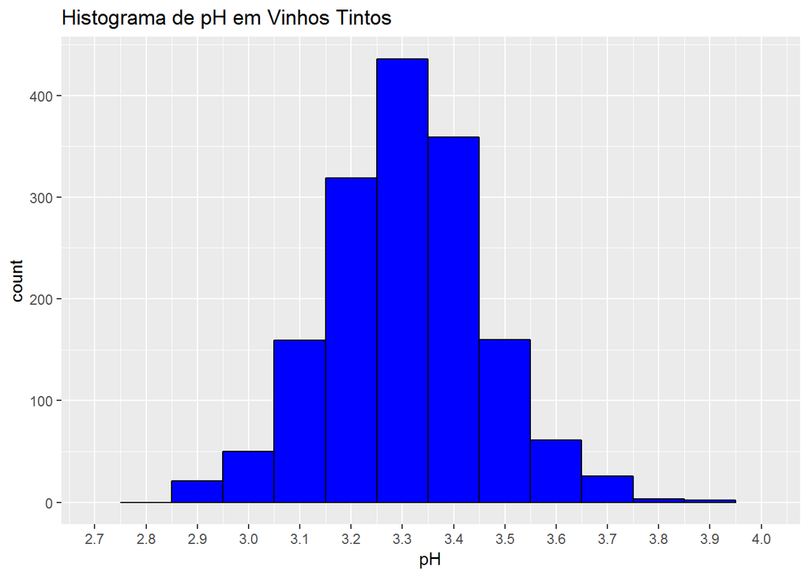

```r
ggplot(data = wine, aes(x=pH))+
  geom_histogram(binwidth = .1, color = 'black', fill = 'blue')+
  scale_x_continuous(limits = c(2.700,4.010), breaks = seq(2.7,4.1,.1))+
  labs(title = 'Histograma de pH em Vinhos Tintos')
```

Assim como density, pH parece ser normalmente distribuido

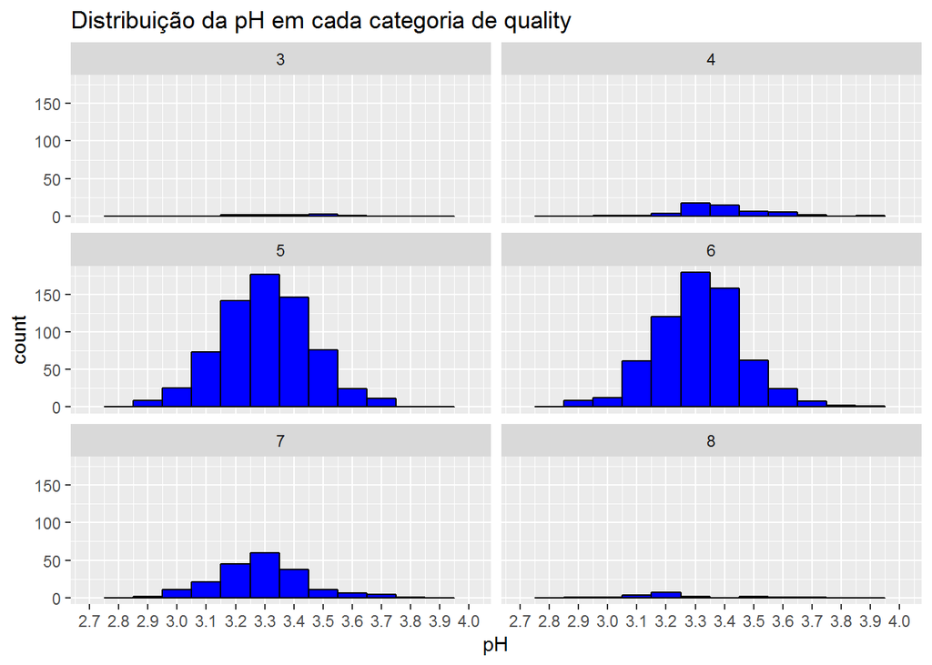

```r
ggplot(data = wine, aes(x=pH))+
  geom_histogram(binwidth = 0.1, color = 'black', fill = 'blue')+
  scale_x_continuous(limits = c(2.700,4.010), breaks = seq(2.7,4.1,.1))+
  facet_wrap(  ~ quality, ncol=2)+
  labs(title = 'Distribuição da pH em cada categoria de quality')
```

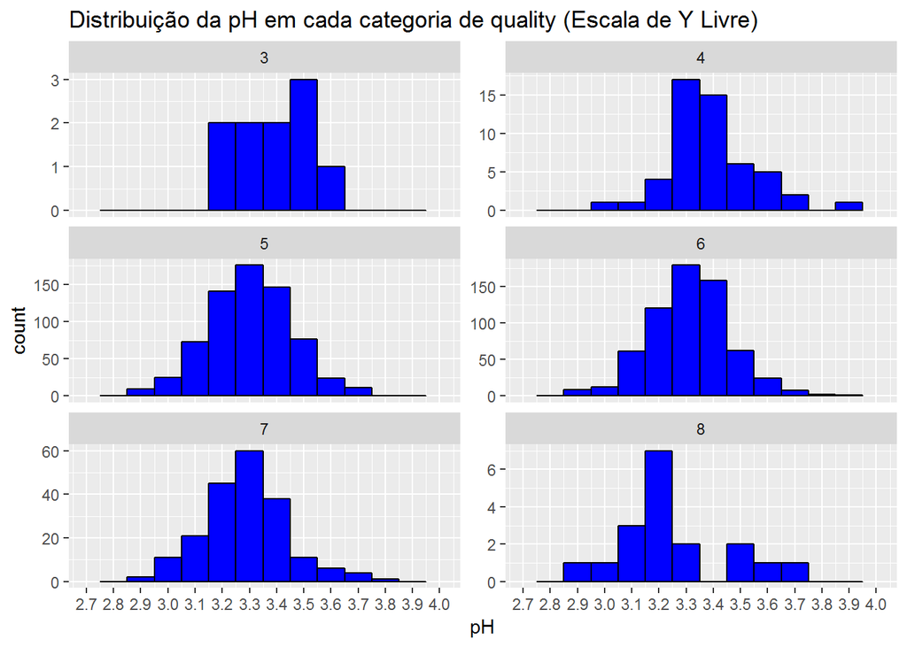

```r
ggplot(data = wine, aes(x=pH))+
  geom_histogram(binwidth = .1, color = 'black', fill = 'blue')+
  scale_x_continuous(limits = c(2.700,4.010), breaks = seq(2.7,4.1,.1))+
  facet_wrap(  ~ quality, ncol=2, scales = 'free_y')+
  labs(title = 'Distribuição da pH em cada categoria de quality (Escala de Y Livre)')
```

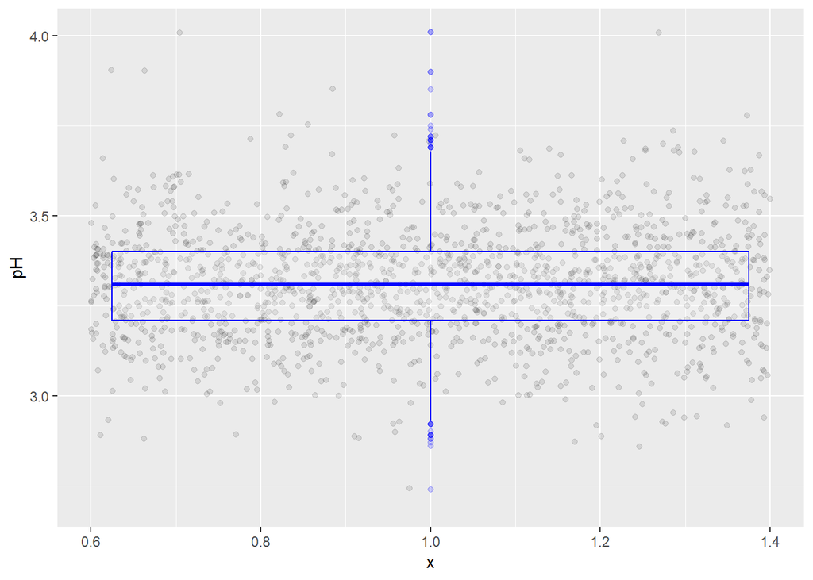

```r
ggplot(wine, aes( x = 1, y = pH ), xlab('Count of wines') ) +
               geom_jitter(alpha = 0.1 ) + # Alpha = 10% (10 pontos para virar um ponto completo)
               geom_boxplot(alpha = 0.2, color = 'blue' ) +
               scale_y_continuous(lim = c(2.700,4.010))
```

```r
by(wine$pH, wine$quality, sum)
```

```
## wine$quality: 3
## [1] 33.98
## --------------------------------------------------------
## wine$quality: 4
## [1] 179.22
## --------------------------------------------------------
## wine$quality: 5
## [1] 2250.67
## --------------------------------------------------------
## wine$quality: 6
## [1] 2116.93
## --------------------------------------------------------
## wine$quality: 7
## [1] 654.86
## --------------------------------------------------------
## wine$quality: 8
## [1] 58.81
```

```r
by(wine$pH, wine$quality, summary)
```

```
## wine$quality: 3
##    Min. 1st Qu.  Median    Mean 3rd Qu.    Max.
##   3.160   3.312   3.390   3.398   3.495   3.630
## --------------------------------------------------------
## wine$quality: 4
##    Min. 1st Qu.  Median    Mean 3rd Qu.    Max.
##   2.740   3.300   3.370   3.382   3.500   3.900
## --------------------------------------------------------
## wine$quality: 5
##    Min. 1st Qu.  Median    Mean 3rd Qu.    Max.
##   2.880   3.200   3.300   3.305   3.400   3.740
## --------------------------------------------------------
## wine$quality: 6
##    Min. 1st Qu.  Median    Mean 3rd Qu.    Max.
##   2.860   3.220   3.320   3.318   3.410   4.010
## --------------------------------------------------------
## wine$quality: 7
##    Min. 1st Qu.  Median    Mean 3rd Qu.    Max.
##   2.920   3.200   3.280   3.291   3.380   3.780
## --------------------------------------------------------
## wine$quality: 8
##    Min. 1st Qu.  Median    Mean 3rd Qu.    Max.
##   2.880   3.163   3.230   3.267   3.350   3.720
```

#### “sulphates”

Def: Awine additive which can contribute to sulfur dioxide gas (S02) levels, wich acts as an antimicrobial and antioxidant

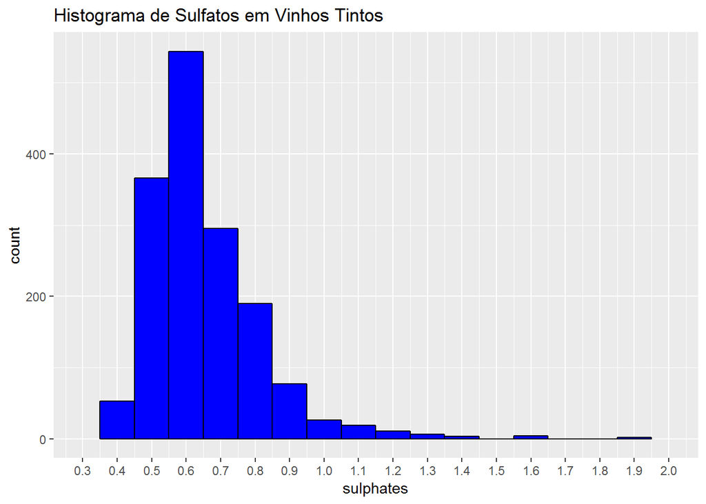

```r
ggplot(data = wine, aes(x=sulphates))+
  geom_histogram(binwidth = .1, color = 'black', fill = 'blue')+
  scale_x_continuous(limits = c(0.3,2), breaks = seq(0.3,2,.1))+
  labs(title = 'Histograma de Sulfatos em Vinhos Tintos')
```

Distribuição de cauda longa, muito parecida com outras variaveis do banco de dados. Provavelmente existe uma correlação.

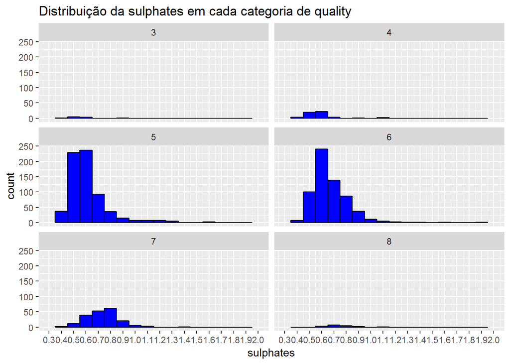

```r
ggplot(data = wine, aes(x=sulphates))+
  geom_histogram(binwidth = 0.1, color = 'black', fill = 'blue')+
  scale_x_continuous(limits = c(0.3,2), breaks = seq(0.3,2,.1))+
  facet_wrap(  ~ quality, ncol=2)+
  labs(title = 'Distribuição da sulphates em cada categoria de quality')
```

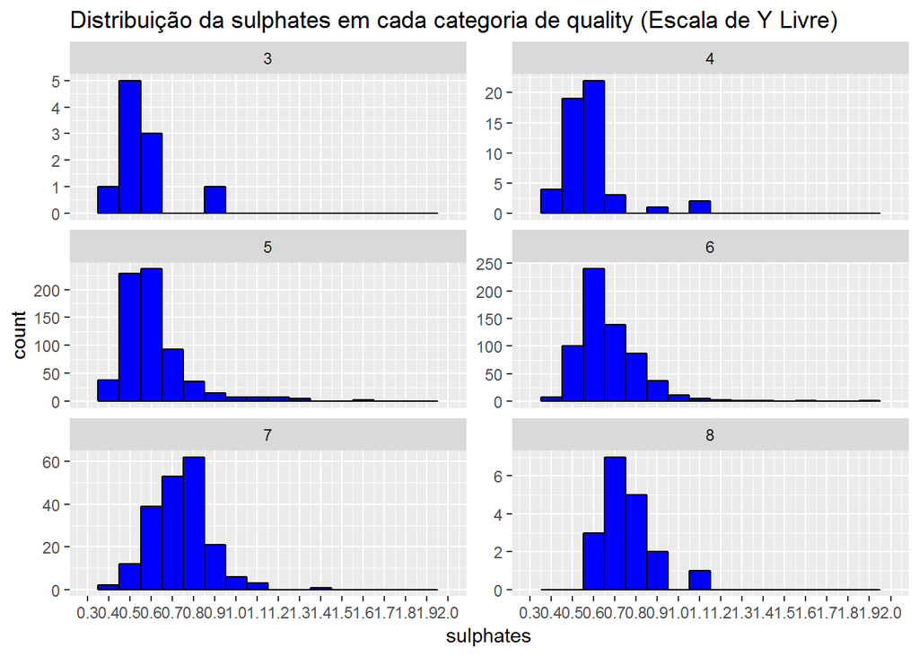

```r
ggplot(data = wine, aes(x=sulphates))+
  geom_histogram(binwidth = .1, color = 'black', fill = 'blue')+
  scale_x_continuous(limits = c(0.3,2), breaks = seq(0.3,2,.1))+
  facet_wrap(  ~ quality, ncol=2, scales = 'free_y')+
  labs(title = 'Distribuição da sulphates em cada categoria de quality (Escala de Y Livre)')
```

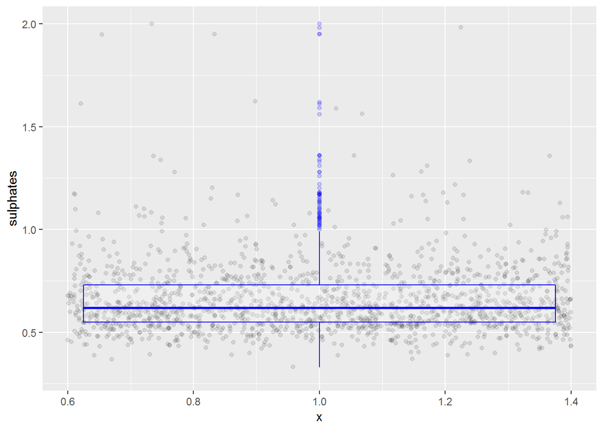

```r
ggplot(wine, aes( x = 1, y = sulphates ), xlab('Count of wines') ) +
               geom_jitter(alpha = 0.1 ) + # Alpha = 10% (10 pontos para virar um ponto completo)
               geom_boxplot(alpha = 0.2, color = 'blue' ) +
               scale_y_continuous(lim = c(0.3,2))
```

```r
by(wine$sulphates, wine$quality, sum)
```

```
## wine$quality: 3
## [1] 5.7
## --------------------------------------------------------
## wine$quality: 4
## [1] 31.61
## --------------------------------------------------------
## wine$quality: 5
## [1] 422.88
## --------------------------------------------------------
## wine$quality: 6
## [1] 430.86
## --------------------------------------------------------
## wine$quality: 7
## [1] 147.51
## --------------------------------------------------------
## wine$quality: 8
## [1] 13.82
```

```r
by(wine$sulphates, wine$quality, summary)
```

```
## wine$quality: 3
##    Min. 1st Qu.  Median    Mean 3rd Qu.    Max.
##  0.4000  0.5125  0.5450  0.5700  0.6150  0.8600
## --------------------------------------------------------
## wine$quality: 4
##    Min. 1st Qu.  Median    Mean 3rd Qu.    Max.
##  0.3300  0.4900  0.5600  0.5964  0.6000  2.0000
## --------------------------------------------------------
## wine$quality: 5
##    Min. 1st Qu.  Median    Mean 3rd Qu.    Max.
##   0.370   0.530   0.580   0.621   0.660   1.980
## --------------------------------------------------------
## wine$quality: 6
##    Min. 1st Qu.  Median    Mean 3rd Qu.    Max.
##  0.4000  0.5800  0.6400  0.6753  0.7500  1.9500
## --------------------------------------------------------
## wine$quality: 7
##    Min. 1st Qu.  Median    Mean 3rd Qu.    Max.
##  0.3900  0.6500  0.7400  0.7413  0.8300  1.3600
## --------------------------------------------------------
## wine$quality: 8
##    Min. 1st Qu.  Median    Mean 3rd Qu.    Max.
##  0.6300  0.6900  0.7400  0.7678  0.8200  1.1000
```

#### “alcohol”

Def: The percent alcohol content of the wine

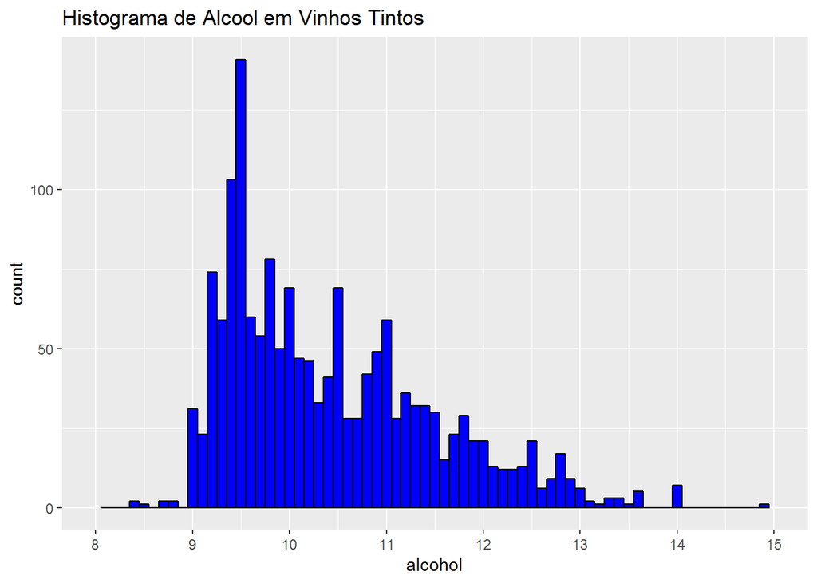

```r
ggplot(data = wine, aes(x=alcohol))+
  geom_histogram(binwidth = 0.1, color = 'black', fill = 'blue')+
  scale_x_continuous(limits = c(8,15), breaks = seq(8,15,1))+
  labs(title = 'Histograma de Alcool em Vinhos Tintos')
```

Tem uma forma similar ao grafico dos açucares residuais, poderia haver uma correlação.

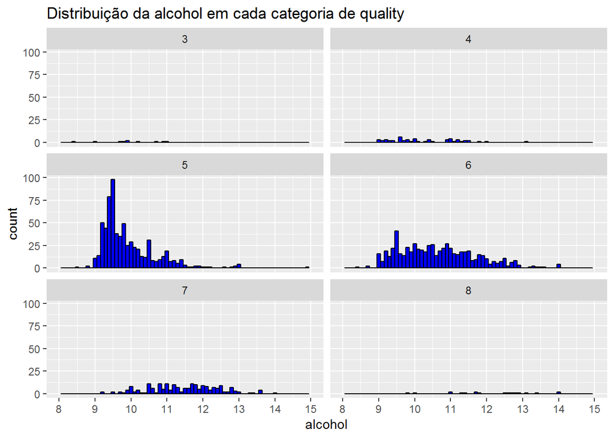

```r
ggplot(data = wine, aes(x=alcohol))+
  geom_histogram(binwidth = 0.1, color = 'black', fill = 'blue')+
  scale_x_continuous(limits = c(8,15), breaks = seq(8,15,1))+
  facet_wrap(  ~ quality, ncol=2)+
  labs(title = 'Distribuição da alcohol em cada categoria de quality')
```

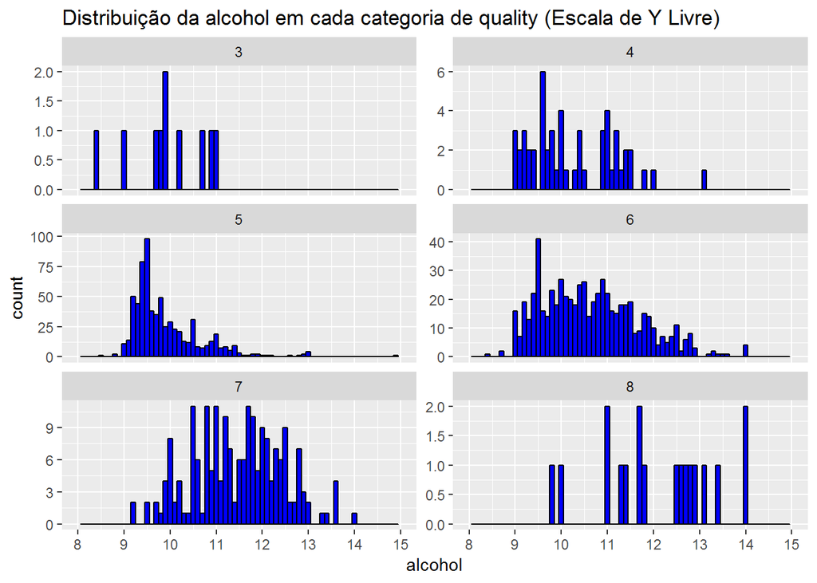

```r
ggplot(data = wine, aes(x=alcohol))+
  geom_histogram(binwidth = .1, color = 'black', fill = 'blue')+
  scale_x_continuous(limits = c(8,15), breaks = seq(8,15,1))+
  facet_wrap(  ~ quality, ncol=2, scales = 'free_y')+
  labs(title = 'Distribuição da alcohol em cada categoria de quality (Escala de Y Livre)')
```

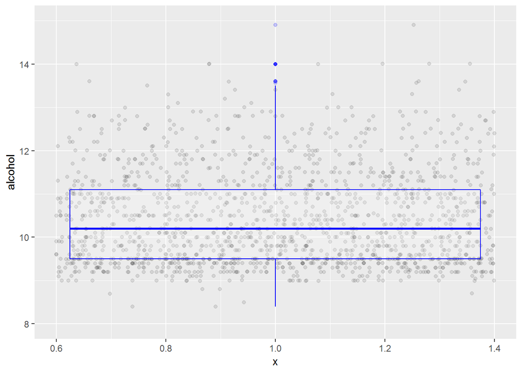

```r
ggplot(wine, aes( x = 1, y = alcohol ), xlab('Count of wines') ) +
               geom_jitter(alpha = 0.1 ) + # Alpha = 10% (10 pontos para virar um ponto completo)
               geom_boxplot(alpha = 0.2, color = 'blue' ) +
               scale_y_continuous(lim = c(8,15))
```

```r
by(wine$alcohol, wine$quality, sum)
```

```
## wine$quality: 3
## [1] 99.55
## --------------------------------------------------------
## wine$quality: 4
## [1] 544.05
## --------------------------------------------------------
## wine$quality: 5
## [1] 6741.7
## --------------------------------------------------------
## wine$quality: 6
## [1] 6781.633
## --------------------------------------------------------
## wine$quality: 7
## [1] 2281.717
## --------------------------------------------------------
## wine$quality: 8
## [1] 217.7
```

```r
by(wine$alcohol, wine$quality, summary)
```

```
## wine$quality: 3
##    Min. 1st Qu.  Median    Mean 3rd Qu.    Max.
##   8.400   9.725   9.925   9.955  10.575  11.000
## --------------------------------------------------------
## wine$quality: 4
##    Min. 1st Qu.  Median    Mean 3rd Qu.    Max.
##    9.00    9.60   10.00   10.27   11.00   13.10
## --------------------------------------------------------
## wine$quality: 5
##    Min. 1st Qu.  Median    Mean 3rd Qu.    Max.
##     8.5     9.4     9.7     9.9    10.2    14.9
## --------------------------------------------------------
## wine$quality: 6
##    Min. 1st Qu.  Median    Mean 3rd Qu.    Max.
##    8.40    9.80   10.50   10.63   11.30   14.00
## --------------------------------------------------------
## wine$quality: 7
##    Min. 1st Qu.  Median    Mean 3rd Qu.    Max.
##    9.20   10.80   11.50   11.47   12.10   14.00
## --------------------------------------------------------
## wine$quality: 8
##    Min. 1st Qu.  Median    Mean 3rd Qu.    Max.
##    9.80   11.32   12.15   12.09   12.88   14.00
```

OBS: Todas definições foram extraídas do site (Kaggle)!https://www.kaggle.com/uciml/red-wine-quality-cortez-et-al-2009 e UCI!https://archive.ics.uci.edu/ml/datasets/wine+quality.

### Qual é a estrutura do conjunto de dados?

Baseado no gráfico acima, eu diria que temos um banco de dados com muitas informações agrupadas e bastantes outliers para certos atributos (e.g: cholorides, residual.sugars,etc.) Iremos detalhar melhor estas distribuições durante o desenvolvimento do projeto.

Existem 1599 linhas (observações) no nosso banco de dados com 12 atributos cada. Exite uma variavel categorica (quality) e 11 numericas que indicam resultados de analises quimicas nos vinhos testados.

### Quais são os principais atributos de interesse deste conjunto de dados?

Na minha opinião a variavel mais importante é a qualidade do vinho (quality), apesar de não sabermos a formula usada para esta nota meu objetivo é encontrar a relação das outras variaveis com a nota de qualidade recebida.

### Quais outros atributos você acha que podem lhe auxiliar na investigação destes atributos de interesse?

Acredito que as variaveis que indicam acidez do vinho (fixed.acidity,volatile.acidity, citric.acid,ph) e a variavel de açucar residual sejam as que mais impactem no sabor e na qualidade.

### Você criou novas variáveis a partir dos atributos existentes no conjunto de dados?

Sim, criei a variavel de sweetness. Baseado na definição, procurei saber qual era a escala de doçura dos vinhos tintos. http://www.winedryness.com/

Utilizei os quartis para definir os niveis, mas devido aos outliers, a maioria dos vinhos foi classificado como “Very Sweer”.

### Dos atributos investigados, distribuições incomuns foram encontradas? Você aplicou operações nos dados para limpá-los, ajustá-los ou mudar a forma dos dados? Se sim, por quê?

Encontrei algumas variaveis com muitos outliers, pelas funções de limite + quantile eu limitei a visualização para que mostrasse somente 95% dos dados.

Também foi necessário ajustar o *binwidth* para cada um dos histogramas para um melhor entendimento.

# Seção de Gráficos Bivariados

```
##                      fixed.acidity volatile.acidity citric.acid
## fixed.acidity                1.000           -0.256       0.672
## volatile.acidity            -0.256            1.000      -0.552
## citric.acid                  0.672           -0.552       1.000
## residual.sugar               0.115            0.002       0.144
## chlorides                    0.094            0.061       0.204
## free.sulfur.dioxide         -0.154           -0.011      -0.061
## total.sulfur.dioxide        -0.113            0.076       0.036
## density                      0.668            0.022       0.365
## pH                          -0.683            0.235      -0.542
## sulphates                    0.183           -0.261       0.313
## alcohol                     -0.062           -0.202       0.110
## quality                      0.124           -0.391       0.226
##                      residual.sugar chlorides free.sulfur.dioxide
## fixed.acidity                 0.115     0.094              -0.154
## volatile.acidity              0.002     0.061              -0.011
## citric.acid                   0.144     0.204              -0.061
## residual.sugar                1.000     0.056               0.187
## chlorides                     0.056     1.000               0.006
## free.sulfur.dioxide           0.187     0.006               1.000
## total.sulfur.dioxide          0.203     0.047               0.668
## density                       0.355     0.201              -0.022
## pH                           -0.086    -0.265               0.070
## sulphates                     0.006     0.371               0.052
## alcohol                       0.042    -0.221              -0.069
## quality                       0.014    -0.129              -0.051
##                      total.sulfur.dioxide density     pH sulphates alcohol
## fixed.acidity                      -0.113   0.668 -0.683     0.183  -0.062
## volatile.acidity                    0.076   0.022  0.235    -0.261  -0.202
## citric.acid                         0.036   0.365 -0.542     0.313   0.110
## residual.sugar                      0.203   0.355 -0.086     0.006   0.042
## chlorides                           0.047   0.201 -0.265     0.371  -0.221
## free.sulfur.dioxide                 0.668  -0.022  0.070     0.052  -0.069
## total.sulfur.dioxide                1.000   0.071 -0.066     0.043  -0.206
## density                             0.071   1.000 -0.342     0.149  -0.496
## pH                                 -0.066  -0.342  1.000    -0.197   0.206
## sulphates                           0.043   0.149 -0.197     1.000   0.094
## alcohol                            -0.206  -0.496  0.206     0.094   1.000
## quality                            -0.185  -0.175 -0.058     0.251   0.476
##                      quality
## fixed.acidity          0.124
## volatile.acidity      -0.391
## citric.acid            0.226
## residual.sugar         0.014
## chlorides             -0.129
## free.sulfur.dioxide   -0.051
## total.sulfur.dioxide  -0.185
## density               -0.175
## pH                    -0.058
## sulphates              0.251
## alcohol                0.476
## quality                1.000
```

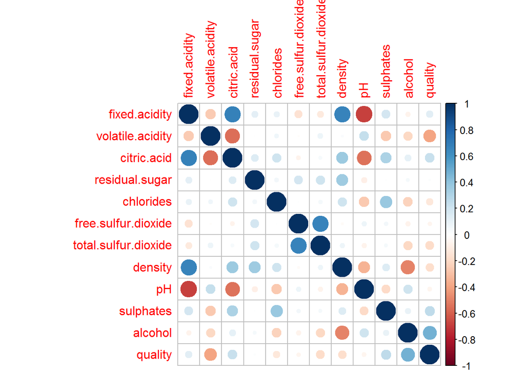

Pela matrix de correlação, podemos confimar algumas suposições que tinhamos.

# Análise Bivariada

Para a análise Bivariada, vamos analisar os seguintes pares.

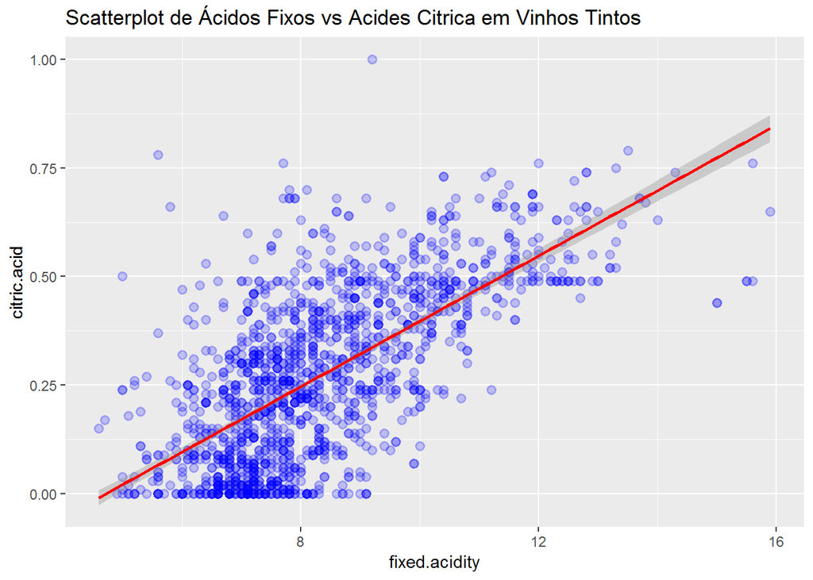

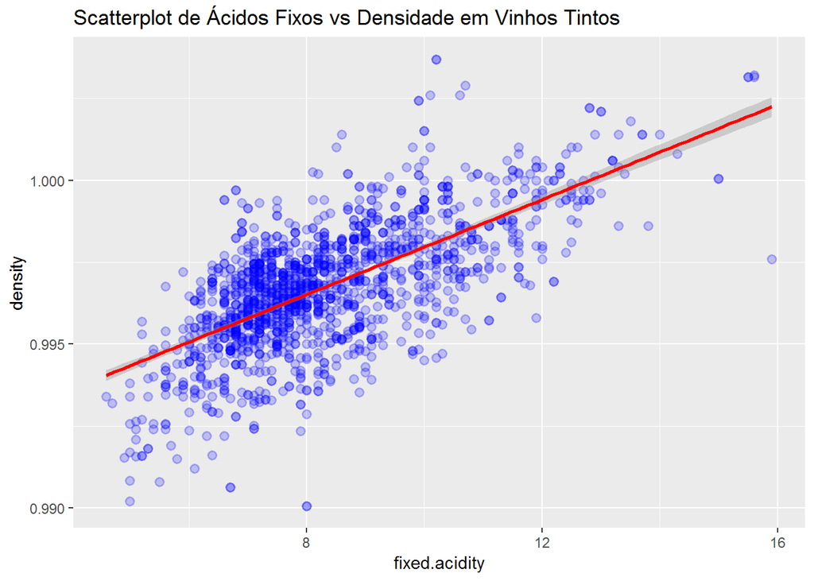

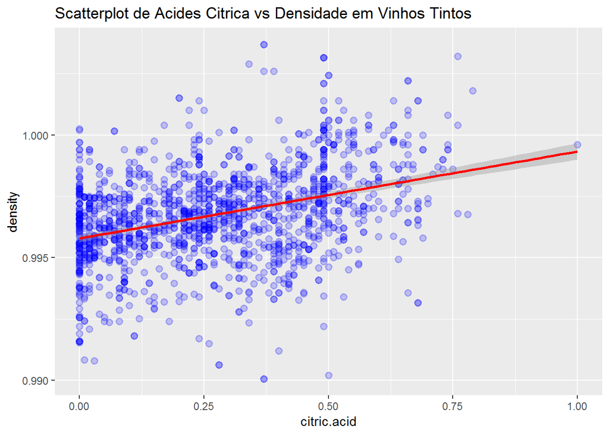

Os três gráficos acima mostram a correlação positiva entre as 3 principais variaveis de intensidade do vinho.

Nas considerações iniciais, tambem vimos que o pH tem uma correlação negativa com a acidez fixa. Acidez fixa, por sua vez tem uma correlação positiva com densidade. Como considero a densidade uma variavel com peso maior na qualidade do vinho, vamos criar um grafico para verificar se a correlação do ph om a densidade existe, e se é positiva ou negativa.

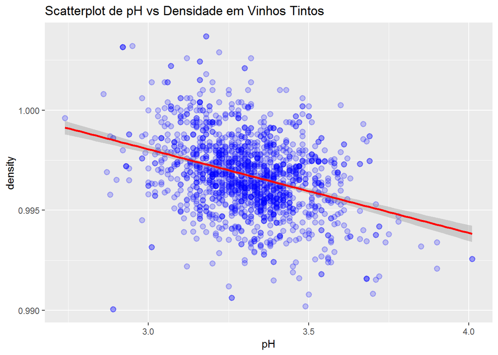

```r
ggplot(wine, aes(x=pH, y=density))+
  geom_point(colour = "blue", fill = "blue", size = 2, stroke = 1, alpha = 1/5)+
  stat_smooth(color='red',method='lm')+
  labs(title='Scatterplot de pH vs Densidade em Vinhos Tintos')
```

Observando o grafico, a massa de dados me parece estar concentrada no meio da distribuição, mas é possivel notar uma pequena correlação negativa entre estes dois atributos.

Tambem observamos uma forte relação entre Alcool e Qualidade, por isto iremos criar um grafico para examinar melhor estes dois atributos.

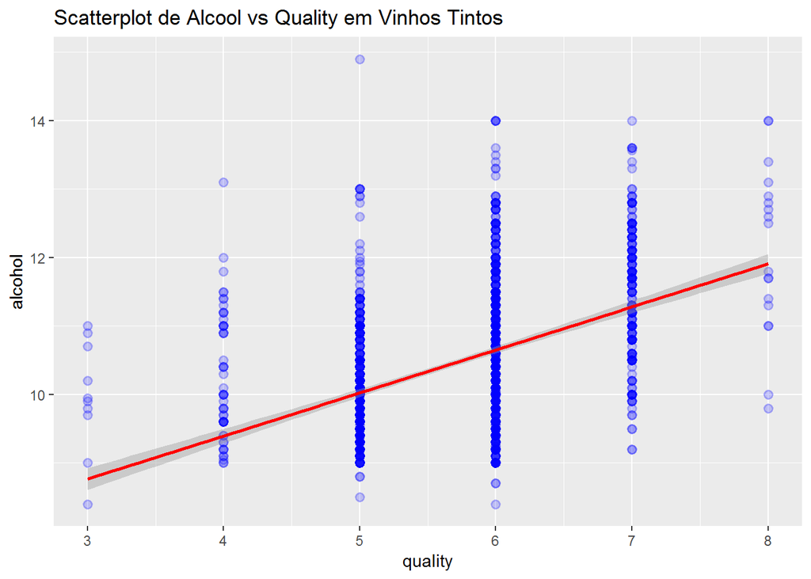

```r
ggplot(wine, aes(x=quality, y=alcohol))+
  geom_point(colour = "blue", fill = "blue", size = 2, stroke = 1, alpha = 1/5)+
  stat_smooth(color='red',method='lm')+
  labs(title='Scatterplot de Alcool vs Quality em Vinhos Tintos')
```

Como podemos perceber, por quality se tratar de uma variável categórica, o sccater ploot não é a visualização mais indicada, por isto iremos utilizar o Boxplot.

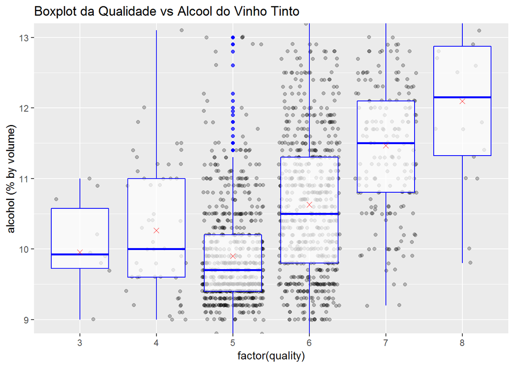

```r
ggplot(wine,aes(x=factor(quality), y = alcohol))+
  geom_jitter(alpha=0.25)+
  geom_boxplot(alpha=0.7, color = 'blue')+
  stat_summary(fun.y = 'mean', geom = 'point',color='red',shape=4,size=2)+
  labs(title='Boxplot da Qualidade vs Alcool do Vinho Tinto',
       y = 'alcohol (% by volume)')+
  coord_cartesian(ylim = c(9,13))
```

### Você observou algum relacionamento interessante entre os outros atributos (os que não são de interesse)?

O que mais me chamou a atenção foi a relação negativa entre o PH e a Densidade e as variaveis que influem sobre acidez do vinho. Meu pensamento inicial é que quanto mais acidez tivessemos, maior seria o pH do vinho. Com a analise bivarial, achamos o oposto deste pensamento.

### Qual foi o relacionamento mais forte encontrado?

Enquanto para o alcohol a correlação é positiva, para a volatile.acidity a correlação é negativa.

# Seção de Gráficos Multivariados

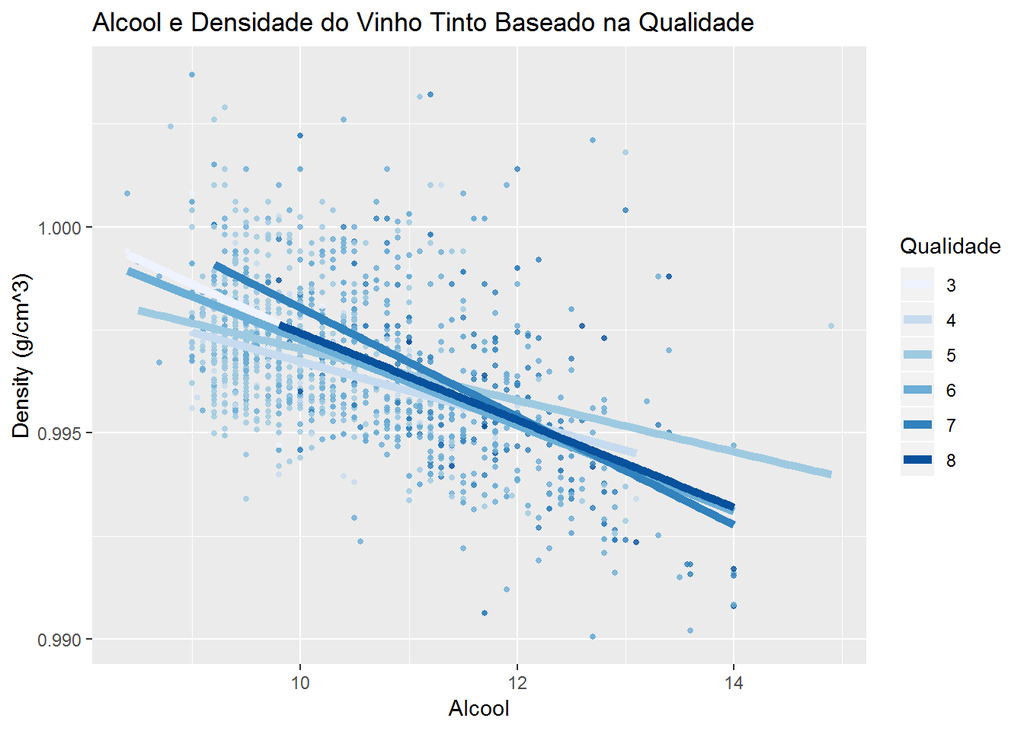

Analisando o grafico acima, a maior massa de amostras parece se encaixar no sentido Esquerda -> Direita, Cima->Baixo quando o alcool aumenta e a densidade diminui.

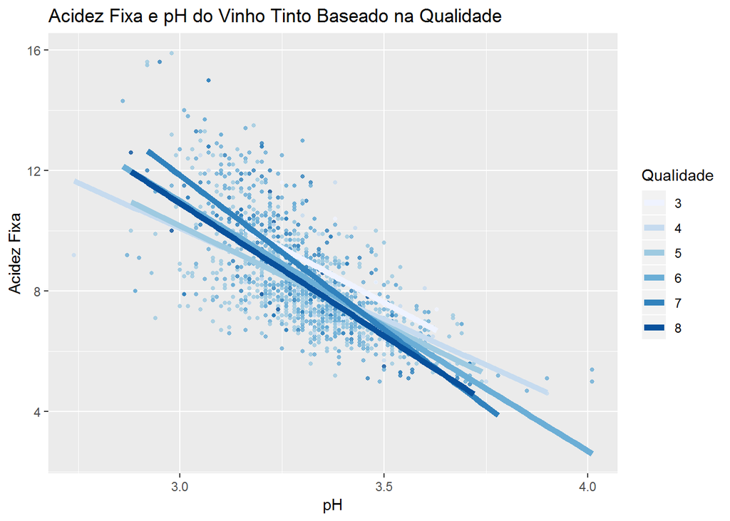

```r
ggplot(data = wine,aes(y=wine$fixed.acidity, x=pH,color=quality))+
  geom_point(size=1,alpha=0.8)+
  geom_smooth(method = 'lm', se = FALSE, size=2)+
  scale_color_brewer(type='seq', guide = guide_legend(title = 'Qualidade'))+
  ggtitle('Acidez Fixa e pH do Vinho Tinto Baseado na Qualidade')+
  labs(x = 'pH',y='Acidez Fixa')
```

Observamos que a maioria dos pontos estão entre os valores de ph 3.0 e 3.5, alem disso conforme aumentamos o PH a Acidez diminui. Os melhores vinhos parecem estar abaixo de 3.5 pH.

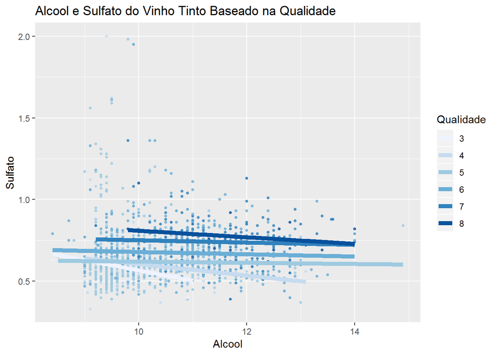

```r
ggplot(data = wine,aes(y=wine$sulphates, x=wine$alcohol,color=quality))+
  geom_point(size=1,alpha=0.8)+
  geom_smooth(method = 'lm', se = FALSE, size=2)+
  scale_color_brewer(type='seq', guide = guide_legend(title = 'Qualidade'))+
  ggtitle('Alcool e Sulfato do Vinho Tinto Baseado na Qualidade')+
  labs(x = 'Alcool',y='Sulfato')
```

# Análise Multivariada

### Discuta sobre os relacionamentos observados nesta parte da investigação. Quais atributos que fortaleceram os demais na observação das variáveis de interesse?

A relação entre acidez fixa e pH parece fortalecer uma à outra. Baixos valores de pH implicam em uma alta acidez e pelos gráficos podemos observar exatamente isto. Tambem podemos observar que niveis elevados de Sulfato e Alcool parecem produzir melhores vinhos.

### Interações surpreendentes e/ou interessantes foram encontradas entre os atributos?

Acredito que a interação mais importante realizada nesta secção, foi entre alcool e densidade por qualidade de vinho. Parece-me que o alcool diminui a densidade e acaba melhorando a qualidade do vinho.

# Gráficos Finais e Sumário

### Primeiro Gráfico

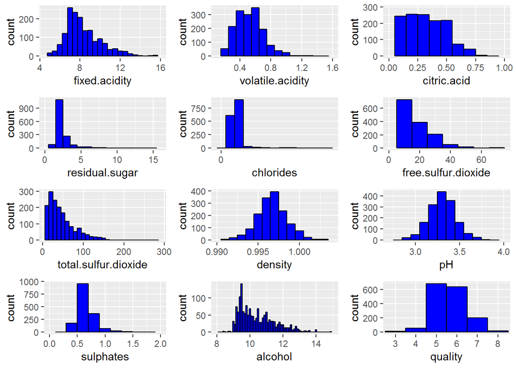

### Descrição do Primeiro Gráfico

Nestre primeiro grafico, buscamos conhecer o nosso dataset. Aqui já é possivel perceber que existem atributos que se aproximam de uma distribuição normal (Density, pH e sulphates). Algumas semelhanças entre os atributos, cujo extrapolamos uma relação como os dioxidos livres e totais alem dos acidos fixos e voláteis.

Tambem não podemos deixar de notar os atributos que contém outliers como residual.sugar, chlorides, sulphates, etc. Isto gera um ponto de atenção para futuras analises.

Porem o dado que mais me chama atenção no nosso dataset é a distribuição de quantidade de amostras entre as qualidades de vinho. Temos uma grande concentração de amostras nas categorias *5* e *6*. Isto tem que ser levado em consideração, quando olhamos as matrizes de sccaterplot.

Alem disto, esta grande concentração em poucas categorias pode tendenciar um futuro modelo de aprendizagem que planejamos utilizar.

### Segundo Gráfico

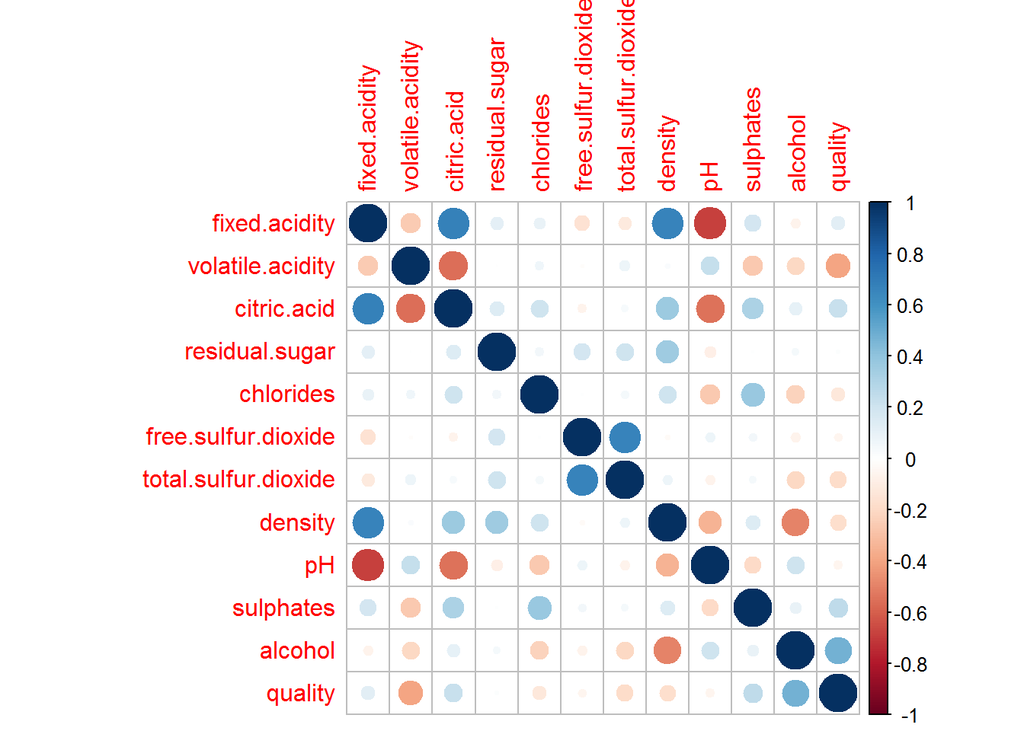

### Descrição do Segundo Gráfico

Após o primeiro contato com o dataset, partimos para a busca de conhecimento dentro dele. Para nos ajudar entender melhor como os atributos se relacionam, minha ideia foi plotar o grafico de matriz de correlação. Aqui cada variável é comparada com outra para gerar uma matriz onde podemos entender quais são as variáveis que melhor se relacionam e quais podem inferir em outras.

Com o gráfico acima, podemos perceber algumas relações, mas a que mais me chamou a atenção foram duas, Alcool x Qualidade (+) e Acidez Volatiz x Qualidade (-). Isso me deixou curioso para entender se a relação entre Alcool e Acidez Volatil seria negativa como a Matriz nos mostra.

### Terceiro Gráfico

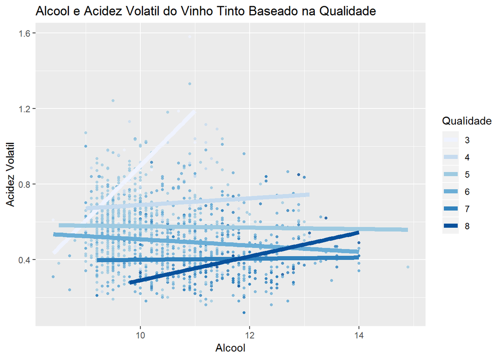

### Descrição do Terceiro Gráfico

No gráfico acima, podemos ver como a relação do Alcool e Acidez pode interferir na qualidade do vinho. Os vinhos de melhor qualidade estão localizados com acidez baixa e alcool relativamente alto. Enquanto os vinhos de qualidade inferior (3 e 4) acabam na outra extremidade do gráfico.

Em minha opinião isto mostra uma relação com a qualidade do vinho, os melhores vinhos estão distribuídos nas quantidades maiores de alcool, porém apenas isto não interfere na qualidade, visto que a maioria dos pontos estão entre 10 e 13. Porém quando adicionamos a Acidez Volatil no gráfico, fica evidente que os melhores vinhos estão na faixa menor de acidez (entre 0.2 e 0.6).

# Reflexão

Considerando que este foi meu primeiro trabalho de EDA em um nivel que considero profissional, minha maior dificuldade foi encontrar as perguntas corretas. É necessário ser criativo e analisar os dados de forma que as informações criadas não induzam ao erro.

Então comecei analizando o formato dos meus dados, quantidade de amostras, quantidade de variaveis, a distribuição de quantidade de dados em cada atributo. Percebi que existiam muitos outliers em alguns atributos, o que me gerou algumas duvidas e receios de utilizar determinado atributo. Após este overview, comecei a explorar cada variavel separadamente. Neste passo descobrimos alguns dados importantes como a distribuição excessiva de amostras nas qualidades 5 e 6, a falta das qualidades 1,2,9 e 10. Isto gerou uma falta de confiança em prever resultados para outras qualidades alem da 5 e 6.

Com uma filtragem simples dos dados para remover alguns dos maiores outliers, comecei a experimentar correlações entre as variaveis. Tentando excluir as relações diretas com qualidade, me chamou a atenção a relação negativa entre o PH e a Densidade e as demais variaveis que influem sobre acidez do vinho. Meu pensamento inicial é que quanto mais acidez tivessemos, maior seria o pH do vinho. Prém com a analise bivarial, encontrei o oposto deste pensamento.

Tambem achei surpreendente que a maioria dos compostos quimicos como residual sugar, chlorides e os dioxidos (total e free sulfur dioxide) não impactam significamente na qualidade do vinho. Meu insigth sobre isto é que eles classificam o vinho em outra categoria, porem não os comparam (e.g. bourbon, frisante, etc.).

Como parte final, eu estava tentando cruzar mais variaveis para tentar encontrar combinações que impactassem na qualidade do vinho. Tentei fazer isto por correlação indireta, como explicado acima no gráfico 3. Apesar de encontrar uma relação com o plot de multivariaveis do gráfico 3 (Alcool x Acide sobre a Qualidade) não é possivel afirmar se esta relação é a causa ou efeito de um vinho bem avaliado.

Para trabalhos futuros, seria ideal ter mais dados sobre outras qualidades de vinho, além de termos notas separadas por jurados onde ada amostra receberia 3 ou 4 notas de diferentes juizes. Além disso seria um bom teste tentar comparar esta base de dados com a base de dados de vinhos brancos para comparar se as mesmas hipoteses levantadas aqui são compativeis para diferentes tipos de vinho.